# Deceptive Student Housing Reviews Predicted Using Deceptive Hotel Reviews

## Background

Student housing complexes in Utah County are rumored to be engaging in deceptive practices like writing deceptive reviews on google maps. This can cause students to have a difficult time finding real information on the apartment complexes that they are going to be living in. Fraudulent review detection is difficult because it can be very domain specific. The goal of this project was to see if deceptive reviews in the domain of student housing can be identified using a model that is trained on a benchmark dataset of deceptive hotel reviews.

## Materials and Methods

Hotel reviews were collected from the Myle Ott deceptive hotel spam dataset. Student housing reviews were scraped off of google maps. The student housing reviews go back 1 year. For each apartment complex and for each month, if a particular month for that apartment had a statistically significantly higher ratio of 5-stars, it was labelled as a ‘spike-month’. A group of 2 former leasing agents got together and labelled 300 different google-reviews as either fake or truthful. Various Machine Learning models were then trained on the Ott dataset and then compared with the externally labeled google-reviews and spike-month labels to compare performance.

## Spike-Month Analysis

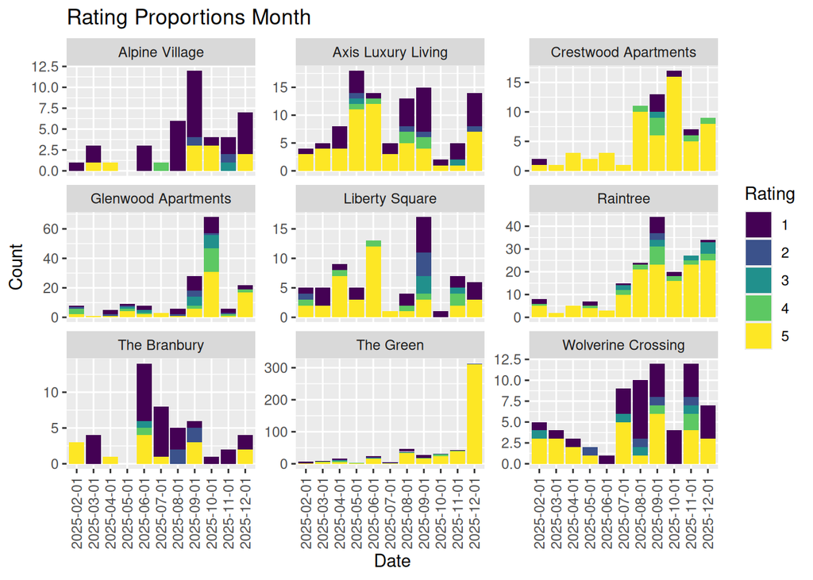

There were a total of 60 observed spike-months in the dataset

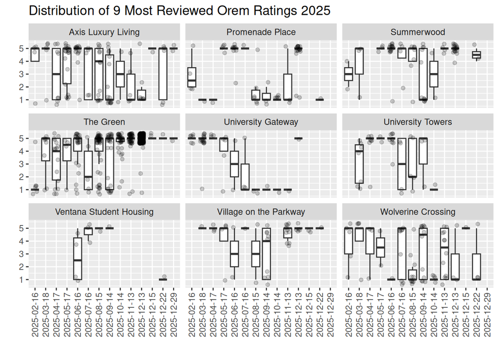

## Machine Learning Models

Various machine learning models were trained on the hotel-review dataset. These were all trained using python.

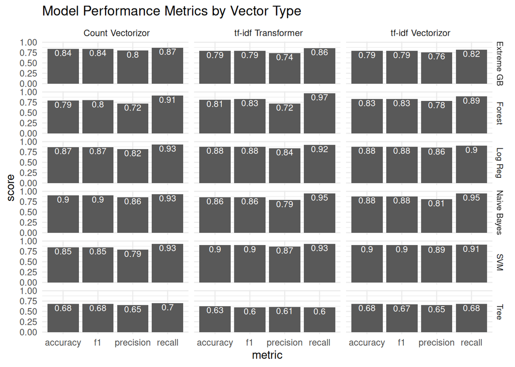

Consistent with the literature, the overall best model was the Support Vector Machine. When a logistic regression was fit predicting model prediction by spike-month (while fixing whether or not a particular review was already 5-stars), the odds ratio of the spike-month predicting a review to be truthful was 2, meaning that the odds of a review being predicted as fake were 2x higher in a spike-month than when it wasn’t.

However, after analyzing the confusion matrix between externally validated data by the former leasing agents, the SVM’s predictions were really only trustworthy if the model predicted a review to be honest.

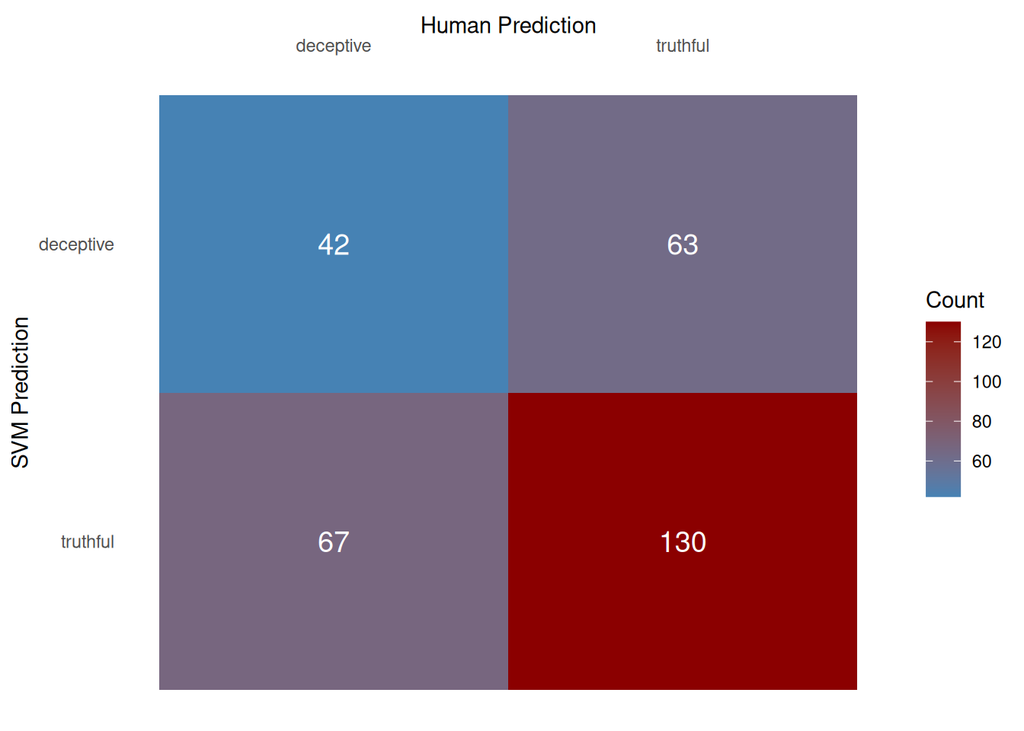

## Conclusions

The Deceptive Hotel Spam dataset was really only effective in building a model that was accurate when it predicted a review to be true, but not when it predicted a review to be false. A larger labelled dataset would be needed to create a model that can more accurately predict when a review is being deceptively written.